# Example creation: the aseg subcortical atlas

## Prerequisites

To successfully run these operations, you must have the following installed on your system, and be running it on either a Linux or Mac. - [FSL](https://fsl.fmrib.ox.ac.uk/fsl/fslwiki/) - [FreeSurfer](https://surfer.nmr.mgh.harvard.edu/) - [R](https://www.r-project.org/) - [ImageMagick](https://imagemagick.org/index.php) - orca

Initiate your R script with the following library calls:

```r
library(ggsegExtra)
library(ggseg)
library(ggseg3d)
library(tidyverse) # for cleaning the atlas data efficiently
```

## Creating a 3d atlas

### The template file

Sub-cortical segmentations are usually stored in volumetric images with `.mgz` extension. These usually also include the cortex, white matter and CSF. Some volumetric segmentations may contain both segmentations of the cortex and the sub-cortex. If you have such a template, we would recommend making a version where the cortex is one large segmentation, and rather create a separate cortical atlas.

### The 3d atlas

We assume the volumetric image you have is for a FreeSurfer subject, specifically registered to the “fsaverage5” subject, which is a good balance between number of vertices and details. If you need to register the volume to “fsaverage5”, there are FreeSurfer tools to help with this, but we have not set up any function for this in R. If you have suggestions or know of an easy command to do this, let us know in the issues so we can try implementing your solution here.

To turn a volumetric image to a ggseg3d-atlas, use the function `make_volumetric_2_3datlas`. This will call a series of FreeSurfer functions to create ascii and ply files for the mesh plots. The function creates several intermediary files which are saved in the output_dir specified.

```r
# Make  3d ----
aseg2_3d <- make_volumetric_2_3datlas(
  subject = "fsaverage5",
  subjects_dir = freesurfer::fs_subj_dir(),
  template = file.path(freesurfer::fs_subj_dir(), "fsaverage5/mri/aseg.mgz"),
  output_dir = "~/Desktop/aseg"
)
```

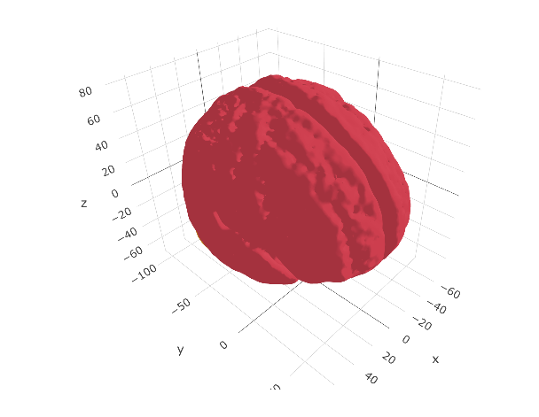

```r
ggseg3d(atlas = aseg2_3d)
```

```r
aseg2_3d
```

```r
# A tibble: 1 x 4
  atlas   surf  hemi              ggseg_3d
  <chr>   <chr> <chr>   <list<tbl_df[,5]>>
1 aseg_3d LCBC  subcort           [43 × 5]
```

### Cleaning the atlas data

The atlas data usually needs some manual editing to get it into a nice shape for other users, and for nice plotting. We are avid [tidyverse](https://www.tidyverse.org/) users, and as such the procedures we use here to clean the data use tidyverse functions.

First, we will unnest the `ggseg_3d` column, so we can see what the atlas data contains.

```r
unnest(aseg2_3d, ggseg_3d)
```

```r
# A tibble: 43 x 8
   atlas   surf  hemi    region                       colour  label                        roi   mesh
   <chr>   <chr> <chr>   <chr>                        <chr>   <chr>                        <chr> <list>
 1 aseg_3d LCBC  subcort Left-Cerebral-White-Matter   #F5F5F5 Left-Cerebral-White-Matter   0002  <named list [2]>
 2 aseg_3d LCBC  subcort Left-Cerebral-Cortex         #CD3E4E Left-Cerebral-Cortex         0003  <named list [2]>
 3 aseg_3d LCBC  subcort Left-Lateral-Ventricle       #781286 Left-Lateral-Ventricle       0004  <named list [2]>
 4 aseg_3d LCBC  subcort Left-Inf-Lat-Vent            #C43AFA Left-Inf-Lat-Vent            0005  <named list [2]>
 5 aseg_3d LCBC  subcort Left-Cerebellum-White-Matter #DCF8A4 Left-Cerebellum-White-Matter 0007  <named list [2]>
 6 aseg_3d LCBC  subcort Left-Cerebellum-Cortex       #E69422 Left-Cerebellum-Cortex       0008  <named list [2]>
 7 aseg_3d LCBC  subcort Left-Thalamus-Proper         #00760E Left-Thalamus-Proper         0010  <named list [2]>
 8 aseg_3d LCBC  subcort Left-Caudate                 #7ABADC Left-Caudate                 0011  <named list [2]>
 9 aseg_3d LCBC  subcort Left-Putamen                 #EC0DB0 Left-Putamen                 0012  <named list [2]>
10 aseg_3d LCBC  subcort Left-Pallidum                #0C30FF Left-Pallidum                0013  <named list [2]>
# … with 33 more rows
```

Usually, it is the `region` column we want to do some cleaning of, to make the names of the regions more human readable. This column is populated by the names to each region as specified in the `template` file.

We can inspect all the unique values in this column, so we can start setting up some logic for renaming the regions.

```r
unnest(aseg2_3d, ggseg_3d) |>
  select(region) |>
  unique() |>
  unlist()
```

```r
                        region1                         region2                         region3                         region4
   "Left-Cerebral-White-Matter"          "Left-Cerebral-Cortex"        "Left-Lateral-Ventricle"             "Left-Inf-Lat-Vent"
                        region5                         region6                         region7                         region8
 "Left-Cerebellum-White-Matter"        "Left-Cerebellum-Cortex"          "Left-Thalamus-Proper"                  "Left-Caudate"
                        region9                        region10                        region11                        region12
                 "Left-Putamen"                 "Left-Pallidum"                 "3rd-Ventricle"                 "4th-Ventricle"
                       region13                        region14                        region15                        region16
                   "Brain-Stem"              "Left-Hippocampus"                 "Left-Amygdala"                           "CSF"
                       region17                        region18                        region19                        region20
          "Left-Accumbens-area"                "Left-VentralDC"                   "Left-vessel"           "Left-choroid-plexus"
                       region21                        region22                        region23                        region24
  "Right-Cerebral-White-Matter"         "Right-Cerebral-Cortex"       "Right-Lateral-Ventricle"            "Right-Inf-Lat-Vent"
                       region25                        region26                        region27                        region28
"Right-Cerebellum-White-Matter"       "Right-Cerebellum-Cortex"         "Right-Thalamus-Proper"                 "Right-Caudate"
                       region29                        region30                        region31                        region32
                "Right-Putamen"                "Right-Pallidum"             "Right-Hippocampus"                "Right-Amygdala"
                       region33                        region34                        region35                        region36
         "Right-Accumbens-area"               "Right-VentralDC"                  "Right-vessel"          "Right-choroid-plexus"
                       region37                        region38                        region39                        region40
           "WM-hypointensities"                  "Optic-Chiasm"                  "CC_Posterior"              "CC_Mid_Posterior"
                       region41                        region42                        region43
                   "CC_Central"               "CC_Mid_Anterior"                   "CC_Anterior"
```

The region names for this atlas mainly need some white space in-between certain words to make the names readable. For instance, all dashes (`-`) can be replaced with white space. We’ll try to see other such patterns and how we can easily alter names so they look nicer.

```r
unnest(aseg2_3d, ggseg_3d) |>
    mutate(region = gsub("-|_", " ", region),
           region = tolower(region),
           region = gsub("cc ", "corpus callosum ", region)
           ) |>
    select(region) |>
    unique() |>
    unlist()
```

```r
                       region1                         region2                         region3                         region4
   "left cerebral white matter"          "left cerebral cortex"        "left lateral ventricle"             "left inf lat vent"
                        region5                         region6                         region7                         region8
 "left cerebellum white matter"        "left cerebellum cortex"          "left thalamus proper"                  "left caudate"
                        region9                        region10                        region11                        region12
                 "left putamen"                 "left pallidum"                 "3rd ventricle"                 "4th ventricle"
                       region13                        region14                        region15                        region16
                   "brain stem"              "left hippocampus"                 "left amygdala"                           "csf"
                       region17                        region18                        region19                        region20
          "left accumbens area"                "left ventraldc"                   "left vessel"           "left choroid plexus"
                       region21                        region22                        region23                        region24
  "right cerebral white matter"         "right cerebral cortex"       "right lateral ventricle"            "right inf lat vent"
                       region25                        region26                        region27                        region28
"right cerebellum white matter"       "right cerebellum cortex"         "right thalamus proper"                 "right caudate"
                       region29                        region30                        region31                        region32
                "right putamen"                "right pallidum"             "right hippocampus"                "right amygdala"
                       region33                        region34                        region35                        region36
         "right accumbens area"               "right ventraldc"                  "right vessel"          "right choroid plexus"
                       region37                        region38                        region39                        region40
           "wm hypointensities"                  "optic chiasm"     "corpus callosum posterior" "corpus callosum mid posterior"
                       region41                        region42                        region43
      "corpus callosum central"  "corpus callosum mid anterior"      "corpus callosum anterior"
```

Once we are satisfied with the region names, we should also alter the atlas name in the data, to something a little more pleasing.

```r
unnest(aseg2_3d, ggseg_3d) |>
    mutate(region = gsub("-|_", " ", region),
           region = tolower(region),
           region = gsub("cc ", "corpus callosum ", region),

           atlas = "aseg2_3d"
           )
```

```r
# A tibble: 43 x 8
   atlas    surf  hemi    region                       colour  label                        roi   mesh
   <chr>    <chr> <chr>   <chr>                        <chr>   <chr>                        <chr> <list>
 1 aseg2_3d LCBC  subcort left cerebral white matter   #F5F5F5 Left-Cerebral-White-Matter   0002  <named list [2]>
 2 aseg2_3d LCBC  subcort left cerebral cortex         #CD3E4E Left-Cerebral-Cortex         0003  <named list [2]>
 3 aseg2_3d LCBC  subcort left lateral ventricle       #781286 Left-Lateral-Ventricle       0004  <named list [2]>
 4 aseg2_3d LCBC  subcort left inf lat vent            #C43AFA Left-Inf-Lat-Vent            0005  <named list [2]>
 5 aseg2_3d LCBC  subcort left cerebellum white matter #DCF8A4 Left-Cerebellum-White-Matter 0007  <named list [2]>
 6 aseg2_3d LCBC  subcort left cerebellum cortex       #E69422 Left-Cerebellum-Cortex       0008  <named list [2]>
 7 aseg2_3d LCBC  subcort left thalamus proper         #00760E Left-Thalamus-Proper         0010  <named list [2]>
 8 aseg2_3d LCBC  subcort left caudate                 #7ABADC Left-Caudate                 0011  <named list [2]>
 9 aseg2_3d LCBC  subcort left putamen                 #EC0DB0 Left-Putamen                 0012  <named list [2]>
10 aseg2_3d LCBC  subcort left pallidum                #0C30FF Left-Pallidum                0013  <named list [2]>
# … with 33 more rows
```

Of note, at this stage, you can also add *other columns* of importance to the atlas. As long as these to not conflict in terms of names with the default atlas columns, you can add as many extra columns as you wish. For instance, if this is an atlas based on connectivity, there might be a nested structure to the regions, such that certain regions together form a specific network. Adding a `network` column specifying which regions belong to which network is then appropriate.

The data include too much though! We cannot see the sub-cortical structures because the entire cortex is in the way. We should delete the any unnecessary meshes as a whole from the data, so we are only left with sub-cortical structures.

```r
aseg2_3d <- unnest(aseg2_3d, ggseg_3d) |>
    mutate(region = gsub("-|_", " ", region),
           region = tolower(region),
           region = gsub("cc ", "corpus callosum ", region),

           atlas = "aseg2_3d"
    ) |>
    filter(!grepl("Cortex|White-Matter", label))
```

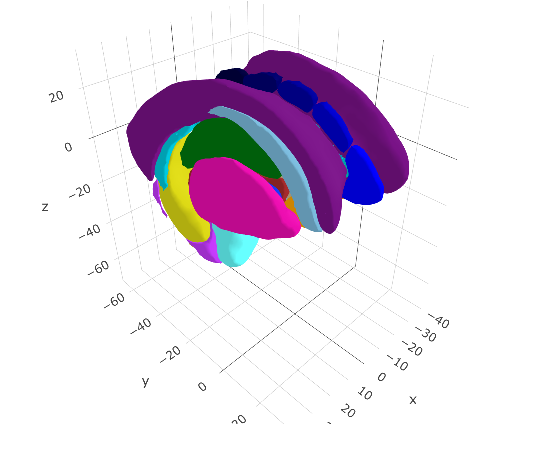

```r
ggseg3d(atlas = aseg2_3d)
```

### Finalizing the atlas

We are now happy with the atlas data we’ve cleaned, so we can go ahead and make it into a ggseg3d-atlas class again by nesting the atlas data by surface and hemisphere

```r
aseg2_3d <- aseg2_3d |>
  nest_by(atlas, surf, hemi, .key = "ggseg_3d") |>
  as_ggseg3d_atlas()

aseg2_3d
```

```r
# A tibble: 1 x 4
  atlas    surf  hemi    ggseg_3d
  <chr>    <chr> <chr>   <list>
1 aseg2_3d LCBC  subcort <tibble [35 × 5]>
```

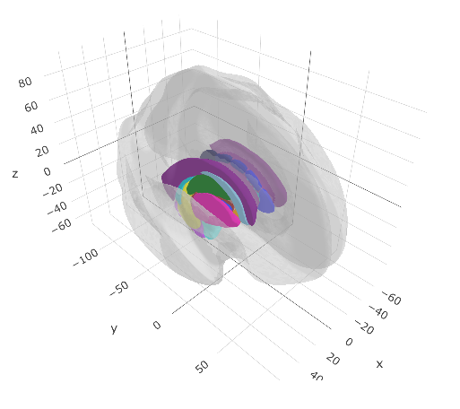

```r
ggseg3d(atlas = aseg2_3d) |>
  add_glassbrain()
```

## Creating the 2d atlas

The creation function need a data.frame with information on which slices to snapshot using Freeview.

```r
slices <- data.frame(x = c(130, 122, 122),
           y = c(130, 235, 112),
           z = c(130, 100, 106),
           view = c("axial", "sagittal", "coronal"),
           stringsAsFactors = FALSE)
slices
```

This data.frame is provided to the `slices` arguments, and will ultimately become the slices in your plot.

```r
# make atlas ----
aseg2 <- make_volumetric_ggseg(
  label_file = file.path(freesurfer::fs_subj_dir(), "fsaverage5", "mri/aseg.mgz"),
  slices = slices,
  vertex_size_limits = c(10, NA)
)
```

```r
● 1/8 Preparing labels
  |==============================================| 100%, Elapsed 00:24
✓ labels ready
● 2/8 Snapshotting views of regions to ~/Desktop/aseg/snapshots,
  |======================================================| 100%, Elapsed 03:20
✓ snapshots complete
● 3/8 isolating regions to ~/Desktop/aseg/interrim
  |======================================================| 100%, Elapsed 00:01
✓ isolation complete
● 4/8 Writing masks to ~/Desktop/aseg/masks
  |======================================================| 100%, Elapsed 00:02
✓ masks complete
● 5/8 Extracting contours from regions
  |======================================================| 100%, Elapsed 00:31
✓ contours complete
● 6/8 Smoothing contours
✓ Smoothing complete
● 7/8 Reducing vertexes
✓ Vertexes reduced
● 8/8 Cleaning up data
● Atlas is complete with 244718 vertices, try re-running steps 7:8 with a higher 'tolerance' number.
✓ cleanup complete
```

The most likely steps to redo are steps 6-8, tweaking the `smoothness` and `tolerance` arguments to improve how the polygons look and how many vertices there are. The fewer vertices, the faster the plot renders, but too few and the polygons will look poor.

### Inspecting the atlas object

First step is to have a look at the actual object. If the brain-atlas is correctly set up, the output should look like the below.

```r
aseg2
```

```r
# aseg subcortical brain atlas
  regions: 19
  hemispheres: NA, left, right
  side views: coronal, sagittal, axial
  palette: yes
  use: ggplot() + geom_brain()
----
   side    hemi  roi   label                      region
   <chr>   <chr> <chr> <chr>                      <chr>
 1 coronal left  0002  Left-Cerebral-White-Matter cerebral white matter
 2 coronal left  0003  Left-Cerebral-Cortex       cerebral cortex
 3 coronal left  0004  Left-Lateral-Ventricle     lateral ventricle
 4 coronal left  0010  Left-Thalamus-Proper       thalamus proper
 5 coronal left  0012  Left-Putamen               putamen
 6 coronal <NA>  0014  3rd-Ventricle              3rd ventricle
 7 coronal <NA>  0016  Brain-Stem                 brain stem
 8 coronal left  0017  Left-Hippocampus           hippocampus
 9 coronal <NA>  0024  CSF                        csf
10 coronal left  0028  Left-VentralDC             ventraldc
# … with 96 more rows
```

Second step is to make sure the data is being plotted correctly.

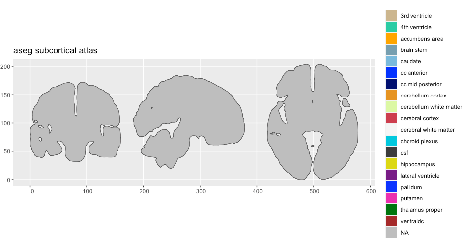

```r
plot(aseg2)
```

We can clearly see something is wrong, but the legend indicated that there is data there we cannot see. Setting the `alpha` might expose something.

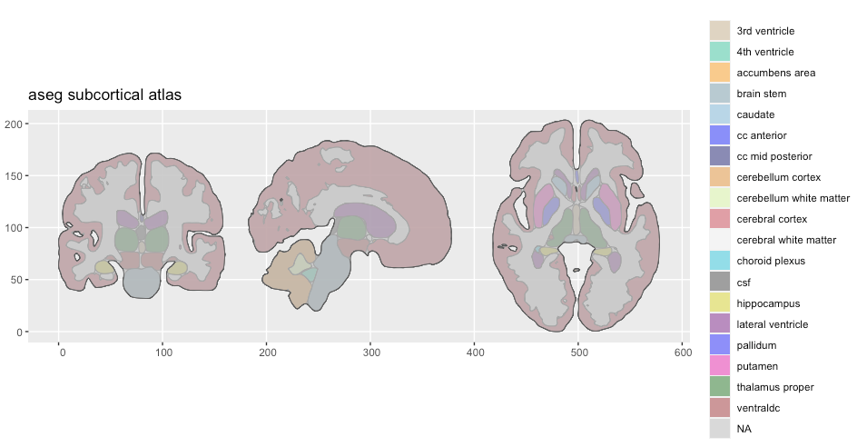

```r
plot(aseg2, alpha = .5)
```

We can see that the polygons are there, but they are hidden behind something. The colour of the polygons indicate that these are `NA` values. Inspecting the atlas data directly is a good idea.

```r
aseg2$data
```

```r
Simple feature collection with 112 features and 5 fields
geometry type:  MULTIPOLYGON
dimension:      XY
bbox:           xmin: 0 ymin: 0 xmax: 578.2364 ymax: 203.3227
CRS:            NA
# A tibble: 112 x 6
   side   hemi  roi                                               geometry label          region
 * <chr>  <chr> <chr>                                       <MULTIPOLYGON> <chr>          <chr>
 1 coron… NA    0000  (((8.596379 105.0979, 8.532187 105.0767, 8.469717 1… Unknown        NA
 2 coron… left  0002  (((82.41844 102.0004, 82.39649 101.9761, 82.37604 1… Left-Cerebral… cerebral wh…
 3 coron… left  0003  (((88.86371 171.1159, 88.76302 171.0871, 88.66764 1… Left-Cerebral… cerebral co…
 4 coron… left  0004  (((101.7151 116.3753, 101.64 116.3752, 101.5623 116… Left-Lateral-… lateral ven…
 5 coron… left  0010  (((100.0108 100.9053, 99.87905 100.9186, 99.74468 1… Left-Thalamus… thalamus pr…
 6 coron… left  0012  (((116.5521 82.86438, 116.5237 82.81094, 116.4955 8… Left-Putamen   putamen
 7 coron… NA    0014  (((78.65921 86.42692, 78.55424 86.38102, 78.45397 8… 3rd-Ventricle  3rd ventric…
 8 coron… NA    0016  (((88.73587 62.17754, 88.62459 62.18198, 88.51179 6… Brain-Stem     brain stem
 9 coron… left  0017  (((113.3849 67.15476, 113.2684 67.12281, 113.1575 6… Left-Hippocam… hippocampus
10 coron… NA    0024  (((78.87844 101.8815, 78.78444 101.8421, 78.69133 1… CSF            csf
# … with 102 more rows
```

We should remove the `NA` data from the atlas, and also the white-matter regions, since these don’t really fit in. Additionally, sub-cortical atlases have the cortex as region `NA` so that these are plotted, but not really treated as true parcellation regions.

```r
aseg2$data <- filter(aseg2$data,
                     !grepl("Unknown", label, ignore.case = TRUE),
                     !grepl("White-matter", label, ignore.case = TRUE)
) |>
  mutate(region = ifelse(grepl("cortex", region), NA, region))

aseg2
```

```r
# aseg subcortical brain atlas
  regions: 15
  hemispheres: left, NA, right
  side views: coronal, sagittal, axial
  palette: yes
  use: ggplot() + geom_brain()
----
   side    hemi  roi   label                   region
   <chr>   <chr> <chr> <chr>                   <chr>
 1 coronal left  0004  Left-Lateral-Ventricle  lateral ventricle
 2 coronal left  0010  Left-Thalamus-Proper    thalamus proper
 3 coronal left  0012  Left-Putamen            putamen
 4 coronal <NA>  0014  3rd-Ventricle           3rd ventricle
 5 coronal <NA>  0016  Brain-Stem              brain stem
 6 coronal left  0017  Left-Hippocampus        hippocampus
 7 coronal <NA>  0024  CSF                     csf
 8 coronal left  0028  Left-VentralDC          ventraldc
 9 coronal right 0043  Right-Lateral-Ventricle lateral ventricle
10 coronal right 0049  Right-Thalamus-Proper   thalamus proper
# … with 70 more rows
```

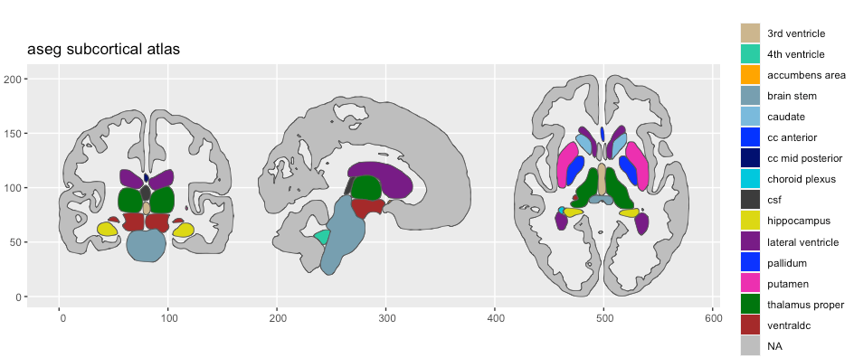

```r
plot(aseg2)
```

In most cases, given the values in the 3d-atlas’ `colour` column is correctly applied, but problems may arise given how annotation files are set up.

### Fixing the palette

Many colour tables have a unique colour for the same regions but in different hemispheres. This can often mess up the palette for the 2d-atlas, which needs the regions in the different hemispheres to have the same palette colour.

If you are working with an atlas that does not have a colour-scheme dispatched with the atlas, the palette should be set to `NULL`.

```r
aseg2$palette <- NULL
aseg2
```

```r
# aseg subcortical brain atlas
  regions: 15
  hemispheres: left, NA, right
  side views: coronal, sagittal, axial
  palette: no
  use: ggplot() + geom_brain()
----
   side    hemi  roi   label                   region
   <chr>   <chr> <chr> <chr>                   <chr>
 1 coronal left  0004  Left-Lateral-Ventricle  lateral ventricle
 2 coronal left  0010  Left-Thalamus-Proper    thalamus proper
 3 coronal left  0012  Left-Putamen            putamen
 4 coronal <NA>  0014  3rd-Ventricle           3rd ventricle
 5 coronal <NA>  0016  Brain-Stem              brain stem
 6 coronal left  0017  Left-Hippocampus        hippocampus
 7 coronal <NA>  0024  CSF                     csf
 8 coronal left  0028  Left-VentralDC          ventraldc
 9 coronal right 0043  Right-Lateral-Ventricle lateral ventricle
10 coronal right 0049  Right-Thalamus-Proper   thalamus proper
# … with 70 more rows
```

When there is no palette, the default atlas plot will return with default ggplot2 colours. This is absolutely a valid option. The palette is an optional part of the atlas.

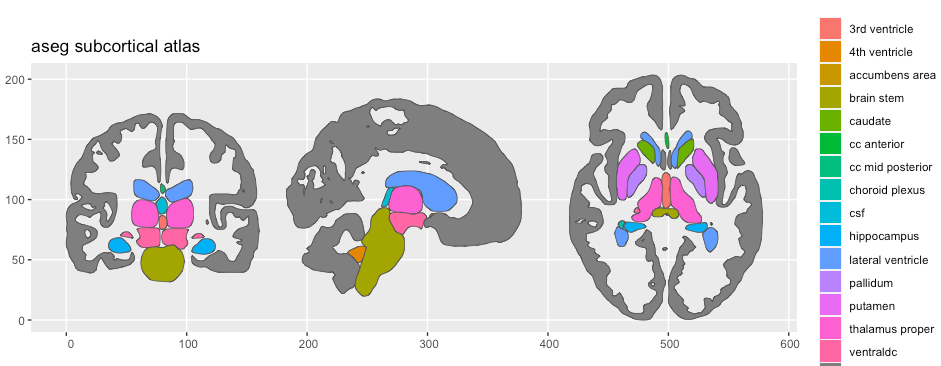

```r
plot(aseg2)
```

If you want to correctly apply a palette, the `aseg2$palette` part of the atlas is a named character vector, where the value of the vector is the hex-colour code, and the names of the elements are the region names as seen in the `region` column of the atlas data.

## Summary

All together, the script to create both 3d and 2d atlases of the aseg parcellation looks like this:

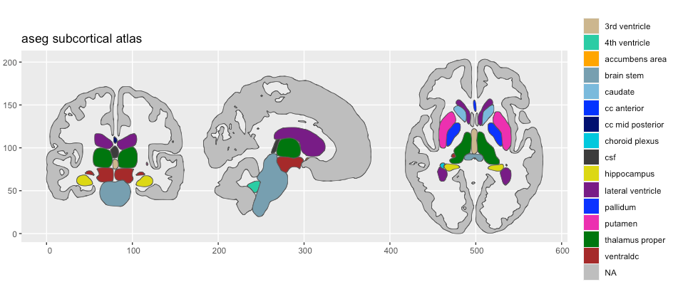

```r
library(ggsegExtra)
library(ggseg)
library(tidyverse)

# Make  3d ----
aseg2_3d <- make_aseg_2_3datlas(
  subject = "fsaverage5",
  subjects_dir = freesurfer::fs_subj_dir(),
  template = file.path(freesurfer::fs_subj_dir(), "fsaverage5", "mri/aseg.mgz"),
  output_dir = "~/Desktop/aseg"
)

ggseg3d(atlas = aseg2_3d)

# make atlas ----
aseg2 <- make_volumetric_ggseg(subject = "fsaverage5",
                               steps = 1:8,
                               output_dir = "~/Desktop/aseg",
                               vertex_size_limits = c(10, NA),
                               label_file = file.path(freesurfer::fs_subj_dir(), "fsaverage5", "mri/aseg.mgz"))

aseg2$data <- filter(aseg2$data,
                     !grepl("Unknown", label, ignore.case = TRUE),
                     !grepl("White-matter", label, ignore.case = TRUE)
) |>
  mutate(region = ifelse(grepl("cortex", region), NA, region))
plot(aseg2, alpha = .8)
```